# Reproducible Research

NicolasGarcesR

7/27/2020

## Loading and preprocessing the data

```r
base<- read.csv("activity.csv", header = TRUE, sep = ',', colClasses = c("numeric", "character", "integer"))
base$date <- ymd(base$date)
head(base)
```

```
##   steps       date interval
## 1    NA 2012-10-01        0
## 2    NA 2012-10-01        5
## 3    NA 2012-10-01       10
## 4    NA 2012-10-01       15
## 5    NA 2012-10-01       20
## 6    NA 2012-10-01       25
```

## What is mean total number of steps taken per day?

- Calculate the total number of steps taken per day

```r
steps <- base %>%
  group_by(date) %>%
  summarize(steps = sum(steps,na.rm = T))
steps
```

```
## # A tibble: 61 x 2
##    date       steps
##    <date>     <dbl>
##  1 2012-10-01     0
##  2 2012-10-02   126
##  3 2012-10-03 11352
##  4 2012-10-04 12116
##  5 2012-10-05 13294
##  6 2012-10-06 15420
##  7 2012-10-07 11015
##  8 2012-10-08     0
##  9 2012-10-09 12811
## 10 2012-10-10  9900
## # … with 51 more rows
```

- Make a histogram of the total number of steps taken each day

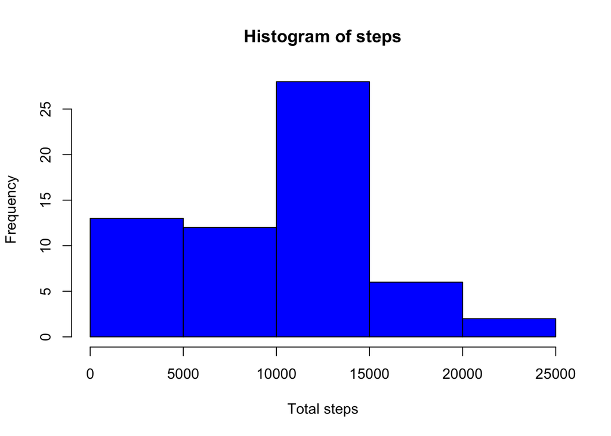

```r
hist(steps$steps, col= "blue", main = "Histogram of steps", xlab = "Total steps" )
```

- Calculate and report the mean and median of the total number of steps taken per day

```r
mean(steps$steps, na.rm = T)
```

```
## [1] 9354.23
```

```r
median(steps$steps, na.rm = T)
```

```
## [1] 10395
```

## What is the average daily activity pattern?

- Make a time series plot of the 5-minute interval (x-axis) and the average number of steps taken, averaged across all days (y-axis)

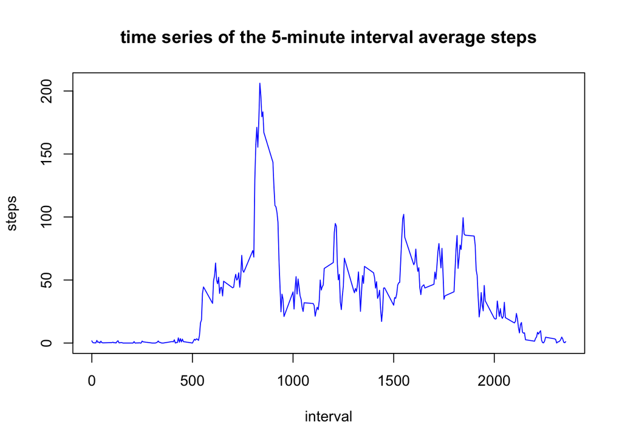

```r
interval <- base %>%
  group_by(interval) %>%
  summarize(steps = mean(steps, na.rm = T))

plot(interval$interval,interval$steps, type = "l", col="blue", main = "time series of the 5-minute interval average steps", xlab = "interval", ylab = "steps")
```

- Which 5-minute interval, on average across all the days in the dataset, contains the maximum number of steps?

```r
interval[max(interval$steps),]
```

[output not shown]

## Imputing missing values

- Calculate and report the total number of missing values in the dataset

```r
sum(is.na(base$steps))
```

```
## [1] 2304
```

- Devise a strategy for filling in all of the missing values in the dataset.

```r
na.steps<- base$steps
steps.mean<- mean(na.steps, na.rm = TRUE)
na.steps[is.na(na.steps)] <- steps.mean
base$steps <- as.numeric(na.steps)
```

- Create a new dataset that is equal to the original dataset but with the missing data filled in.

```r
steps1 <- base%>%
  group_by(date) %>%
  summarize(steps = sum(steps))
```

- Make a histogram of the total number of steps taken each day and Calculate and report the mean and median total number of steps taken per day.

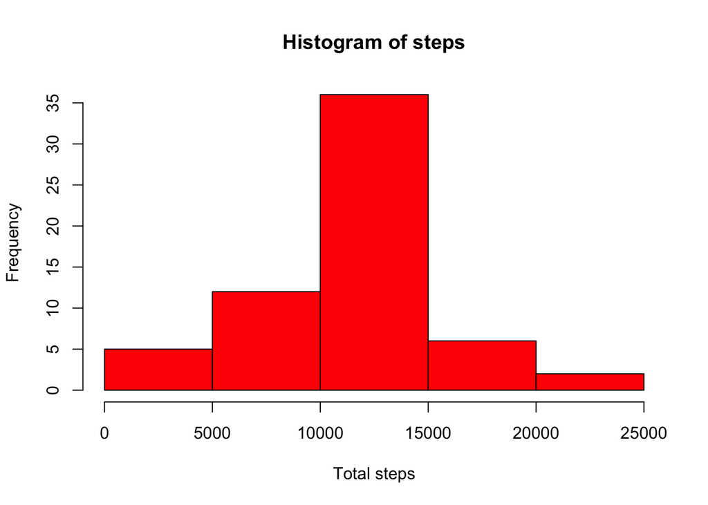

```r
hist(steps1$steps, col= "red", main = "Histogram of steps", xlab = "Total steps" )
```

```r
mean(steps1$steps)
```

```
## [1] 10766.19
```

```r
median(steps1$steps)
```

```
## [1] 10766.19
```

## Are there differences in activity patterns between weekdays and weekends?

- Create a new factor variable in the dataset with two levels – “weekday” and “weekend” indicating whether a given date is a weekday or weekend day.

```r
base<- mutate(base, weektype = ifelse(weekdays(base$date)== "Saturday" |weekdays(base$date)== "Sunday", "weekend", "weekday"))

head(base)
```

```
##     steps       date interval weektype
## 1 37.3826 2012-10-01        0  weekday
## 2 37.3826 2012-10-01        5  weekday
## 3 37.3826 2012-10-01       10  weekday
## 4 37.3826 2012-10-01       15  weekday
## 5 37.3826 2012-10-01       20  weekday
## 6 37.3826 2012-10-01       25  weekday
```

- Make a panel plot containing a time series plot of the 5-minute interval (x-axis) and the average number of steps taken, averaged across all weekday days or weekend days (y-axis)

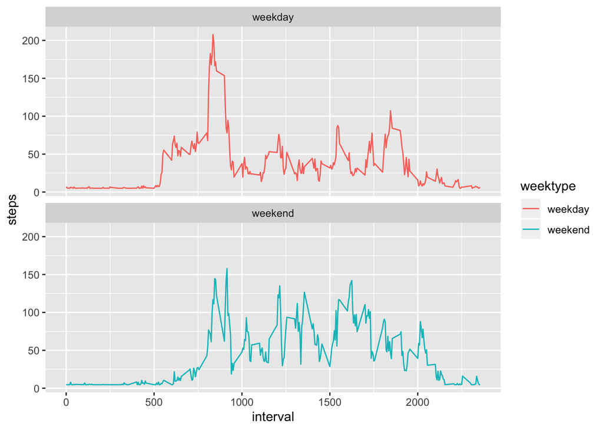

```r
interval1 <- base %>%
  group_by(interval, weektype) %>%
  summarise(steps = mean(steps))
plot<- ggplot(interval1, aes(x=interval, y=steps, color = weektype)) +
  geom_line() +
  facet_wrap(~weektype, ncol = 1, nrow=2)
plot
```